# DATA3888_2024 Lab

Week 1

### Preparation and assumed knowledge

- Have a look at the **Lab** and make sure you have all packages installed on your computer.
- Lab 4B and Lab 4C from DATA2002.
- Produce basic visualisation and generate an Rmarkdown file.

### Aims

- To write basic cross-validation R code from scratch.
- Submit your graph from **exercise 1.3** for formative feedback.
- Understand the difference in interpretation between supervised and unsupervised learning.
- To visualise high-dimensional data.

# 1 Revision from DATA2002: Supervised learning (Classification) and Cross validation

We will use the `pima` data from last year DATA2002 lab. This dataset is originally from the National Institute of Diabetes and Digestive and Kidney Diseases. The dataset’s objective is to diagnostically predict whether or not a patient has diabetes, based on certain diagnostic measurements included in the dataset. Here, we will use **k-nearest neighbours** as the classification method, but you may work through this section using any classifier you wish. We have provided code for the initial processing of the data.

```
library(tidyverse)
library(class)
library(cvTools)
library(randomForest)

pima = read_csv("data/pima.csv")
glimpse(pima)
pima_scaled = pima %>% mutate(y = factor(y)) %>% mutate_if(is.numeric, .funs = scale)
X = pima_scaled %>% select(-y)
y = pima_scaled %>% pull(y)
n = length(y)
```

## 1.1 Test set accuracy

**(a)** Perform k-nearest neighbours on the data with k=5 and calculate an independent test set accuracy.

**(b)** Write a function to calculate estimated accuracy for a vector of the predicted labels (the input is a vector of the true labels and a vector of the predicted labels).

## 1.2 K-fold CV

Perform k-nearest neighbours on the data with k=5 with your own CV code. You are encouraged to write your own code. We’ve created some code scaffolding for students who might find it helpful.

*[Class discussion]* What are some common errors that can happen with this code?

```
K = 5  # number of CV folds

# permute all the data, into 5 folds
cvSets = cvTools::cvFolds(n, K)
glimpse(cvSets)

cv_acc = NA  # initialise results vector

for (j in 1:K) {
    test_id = <write your own code>
    X_test = X[test_id, ]
    X_train = X[-test_id, ]
    y_test = <write your own code>
    y_train = <write your own code>
    fit = class::knn(<write your own code>, k = 5)
    cv_acc[j] = <write your own code>
}
```

## 1.3 Repeated-K-fold CV

What happens if we repeat the calculation of the CV 50 times? In practice, we don’t expect the same CV estimation, but how different are these CV estimations? To answer this question, put an additional “for” loop around your “CV loop” from 1.2 in order to repeat the CV procedure 50 times and visualize your results.

**Submit this result (ONLY) to canvas as a html file or image for formative feedback.**

## 1.4 Comparison

Repeat the previous exercise with a different $k$ value or another classifier and visualise the results together.

# 2 Revision from DATA2002 - clustering

In this section of the exercise, for now, let’s ignore the disease labels and use the unsupervised learning-clustering algorithm to discover some (if any) structure in the data.

## 2.1 K-means

**(a)** Perform k-means clustering on the Pima Indians data (without the y variable) for k = 2. Create a confusion matrix and compare the clusters discovered by the k-means algorithm with the observed diabetic outcomes (`pima$y`). Do these two clusters reflect the outcome of interest? Is the discrepancy a concern?

**(b)** Adjusted Rand Index (ARI) is a metric used to compare two sets of clustering results. Using the function `adjustedRandIndex(x, y)` in the package `mclust`, calculate the ARI between the observed diabetic outcomes and the k-means results. A higher ARI indicates a higher concordance between the two vectors of labels. Before calculating ARI, have a think about what number you expect to see. Please read the **help** file to learn about the function.

## 2.2 Hierarchical Clustering

Let’s examine what happen if we use a different clustering algorithm. Repeat exercise 2.1 using the function `hclust`. Use the function `cutree` to cut a tree into pre-specifying number of groups. Please read the **help** file to learn about the function.

## 2.3 Dimension reduction - PCA

**(a)** Use PCA to perform dimension reduction on the data (again without the y variable). How much of the variation in the data can be explained by the first two principal components?

**(b)** Draw a scatter plot for two selected principal components and visualise the results

- by overlaying the clusters identified by the k-means clustering (code provided below);
- by the diabetes status;
- by age or bmi

*[Class discussion]* What conclusion can you draw from comparing these graphs?

```
pca_pima = prcomp(X)
df_pca <- data.frame(pca_pima$x)
df_pca <- cbind(df_pca, pima)
df_pca$kmeans_cluster <- factor(km$cluster)
ggplot(df_pca, aes(x = PC1, y = PC2, color = kmeans_cluster)) +
  geom_point() +
  theme_bw()
```

# 3 [Extension] Introduction to Case Study 1: Reef

Each week, in the lecture, we will examine a case study, giving you an overview of each of the five projects. If you want to get ahead, you can download the data from the Canvas site and follow the guide below to familiarise yourself with the data.

The first case study will examine a data science question on coral bleaching. Coral bleaching is when coral reefs, under environmental stress (such as change in temperature), release algae in their tissues, causing them to turn white. Bleached corals become susceptible to disease and vulnerable to death. When this happens, the ecosystem is also disrupted. Predicting which environmental factors is associated with bleaching event is therefore important in better managing and preserving coral reefs. In this exercise we will look at a public dataset from the study “Sully, S., Burkepile, D. E., Donovan, M. K., Hodgson, G., & Van Woesik, R. (2019). A global analysis of coral bleaching over the past two decades. Nature communications, 10(1), 1-5”. In this study, the author has curated coral bleaching events at 3351 sites in 81 countries from 1998 to 2017 and a suite of environmental variables at each site.

```r
library(ggplot2)
library(viridis)
library(cvTools)
library(dplyr)
```

## 3.1 Import data

The data we look at today is a standard csv file. The data was collected from two databases. Data on global coral bleaching event can be found at the Reef Check website. Data on environmental variables such as global sea surface temperature and wind speed can be found at the Coral Reef Temperature Anomaly Database (CoRTAD Version 6). Note that all information on CoRTAD are stored in a special data structure called netCDF. Processing the netCDF and matching the coral bleaching records with environmental records can be a bit challenging, which is why we have done this step and provide the final processed data for you.

Inspect the first 6 rows of the coral bleaching data. For a description of each column, please refer to Supplementary Table 1 of the aforementioned study.

```r
reef <- read.csv("data/Reef_Check_with_cortad_variables_with_annual_rate_of_SST_change.csv")
dim(reef)
```

```
## [1] 9215   55
```

```r
head(reef)
```

```
##                    Reef.ID        Reef.Name  Ocean  Country
## 1 103.10.28.1E.10.50.46.1N Koh Mano (Minor) Indian Cambodia
## 2   103.11.35.5E.10.49.32N Koh Mano (south) Indian Cambodia
## 3  103.11.79.5E.10.48.2.7N      Koh Ta Team Indian Cambodia
## 4   103.4.16.8E.11.3.36.2N   Koh Krosa Krao Indian Cambodia
## 5   103.4.63.9E.11.3.58.3N Koh Krosa Kandal Indian Cambodia
## 6  103.5.55.5E.10.53.48.5N        Koh Smach Indian Cambodia
##   State.Province.Island City.Town Year      Date Depth
## 1              Koh Kong           2003 19-Feb-03   4.5
## 2              Koh Kong           2003 28-Feb-03   4.5
## 3              Koh Kong           2003 24-Feb-03   5.0
## 4              Koh Kong           2003 25-Feb-03   6.0
## 5              Koh Kong           2003 27-Feb-03   3.2
## 6              Koh Kong           2003 18-Feb-03   3.0
##                 Organism.Code S1 S2 S3 S4 Errors. What.errors.
```

[output cut: 69 more lines]

## 3.2 Visualisation on world map

Data visualisation is an important component of Data Science, and insightful graphs allow us to effectively communicate information to our target audience. In this course, we begin to transition from static two-dimensional visuals to presenting information using interactive and animated visuals. The column `Average_bleaching` records the percentage of coral reefs across the globe that were recorded as bleached over the sampling periods. We can do the same thing here: use `ggplot` to visualise the percentage of coral reefs on a world map and look at which areas of the world have the most severe coral bleaching.

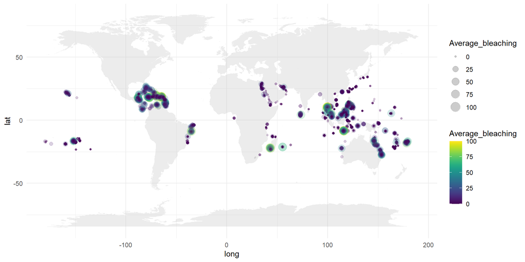

```r
world_map <- map_data("world")

ggplot() + geom_polygon(data = world_map, aes(x = long, y = lat, group = group),
    fill = "grey", alpha = 0.3) + geom_point(data = reef, alpha = 0.2, aes(y = Latitude.Degrees,
    x = Longitude.Degrees, size = Average_bleaching, color = Average_bleaching)) +
    scale_colour_viridis() + theme_minimal()
```

# 4 [Extension] Introduction to Case Study 2: Biomedical data

The second case study will look at biomedical data, aiming to predict kidney transplantation outcome. Kidney transplantation is often the treatment of choice for people with end-stage kidney disease. However, despite advances in the field of transplantation, the proportion of patients who develop graft rejection after a kidney transplant remains high. Understanding the characteristics between stable patients and patients who experience rejection can be one of the ways to improve health outcomes for these people.

In this exercise we will visualise public datasets on kidney transplant patients. We’ll start our investigation by looking at one dataset downloaded from GEO. The [NCBI Gene Expression Omnibus (GEO)](https://www.ncbi.nlm.nih.gov/geo/) is a large public repository of microarray and sequencing-based datasets. You can download the dataset by looking up its GSE ID in the database. Information about each dataset, for example, the paper that this data is published in, the experimental protocol, can also be found on the database. We will first focus on how to analyse the data from “GSE46474”. This dataset contains a group of “discovery” patients and a group of “validation” patients. You can think of it as a “training” and “testing” group. To illustrate visualisation, we will play around with the “discovery” patients. The file `GSE46474_series_matrix.txt.gz` can also be accessed via CANVAS.

## 4.1 Import data

The large file download from GEO may have an impact on your generation of the html file using Rmarkdown code, depending on your internet connection. We’ve provided the data in the form of an `RData` file called `GSE46474.RData`. However, we encourage you to experiment with the following code to see how to import data directly using the `GEOquery` package.

```
library(GEOquery)
library(Biobase)
## import directly from the net
gse <- getGEO("GSE46474")
gse <- gse$GSE46474_series_matrix.txt.gz

## import directly from a locally saved file
Sys.setenv("VROOM_CONNECTION_SIZE" = 131072 * 2) # in case of weird error about VROOM_CONNECTION_SIZE
gse <- getGEO(filename="data/GSE46474_series_matrix.txt.gz")
```

```r
## library(GEOquery) library(Biobase)
load("data/GSE46474.RData")
class(gse)
```

```
## [1] "ExpressionSet"
## attr(,"package")
## [1] "Biobase"
```

```r
gse
```

```
## ExpressionSet (storageMode: lockedEnvironment)
## assayData: 54613 features, 40 samples
##   element names: exprs
## protocolData: none
## phenoData
##   sampleNames: GSM1130812 GSM1130813 ... GSM1130851 (40 total)
##   varLabels: title geo_accession ... tissue:ch1 (46 total)
##   varMetadata: labelDescription
## featureData
##   featureNames: 1007_s_at 1053_at ... NA.25224 (54613 total)
##   fvarLabels: ID GB_ACC ... Gene Ontology Molecular Function (16 total)
##   fvarMetadata: Column Description labelDescription
## experimentData: use 'experimentData(object)'
##   pubMedIds: 25387159
## Annotation: GPL570
```

## 4.2 ExpressionSet

```r
slotNames(gse)
```

```
## [1] "experimentData"    "assayData"         "phenoData"
## [4] "featureData"       "annotation"        "protocolData"
## [7] ".__classVersion__"
```

The ExpressionSet object contains several different slot names. **Explanation of slot names:**

- `experimentData`: Contains *text* information about the design of the experiment.
- `assayData`: Contains a *matrix* of expression values for each gene (feature) measured.
- `phenoData`: Contains a *data frame* of sample information. i.e Covariates.
- `featureData`: Contains a *data frame* of gene (feature) information.
- `annotation`: Contains a *Character* describing the type of platform the samples were sequenced on.

There are other slots but these are rarely used. If you’d like more information on the structure of the ExpressionSet object, you can watch the following [video](https://www.youtube.com/watch?v=5EAOwLDD6Wo). Lets first use the `exprs` function from `Biobase` package. Notice how we have a matrix where our rows are probes which correspond to a gene of interest, and our columns correspond to a sample that has been sequenced.

```r
## BiocManager::install('Biobase')
head(exprs(gse))
```

```
##           GSM1130812 GSM1130813 GSM1130814 GSM1130815 GSM1130816 GSM1130817
## 1007_s_at        5.7        6.5        6.1        6.3        6.0        5.6
## 1053_at          4.8        4.9        4.7        4.5        5.1        4.7
## 117_at           8.0        6.7        7.4        7.7        8.7        8.0
## 121_at           7.6        7.2        7.5        7.4        7.0        7.1
## 1255_g_at        2.8        2.7        2.6        2.3        2.5        2.4
## 1294_at          6.8        6.4        6.6        6.8        7.0        6.5
##           GSM1130818 GSM1130819 GSM1130820 GSM1130821 GSM1130822 GSM1130823
## 1007_s_at        5.9        6.5        6.0        5.8        5.5        6.0
## 1053_at          4.8        5.3        5.0        4.9        4.8        5.2
## 117_at           8.3        8.4        8.0        7.7        8.8        7.7
## 121_at           7.2        6.7        7.2        7.2        6.6        7.3
## 1255_g_at        2.5        2.6        2.5        2.7        2.3        2.5
## 1294_at          7.0        7.1        6.7        6.3        7.0        6.4
##           GSM1130824 GSM1130825 GSM1130826 GSM1130827 GSM1130828 GSM1130829
## 1007_s_at        5.7        5.8        6.1        5.8        6.2        6.3
## 1053_at          4.8        5.3        5.3        4.8        4.5        4.7
## 117_at           8.9        8.3        8.6        7.5        8.8        6.8
## 121_at           7.3        7.3        7.3        7.1        7.5        7.4
## 1255_g_at        2.5        2.4        2.4        2.6        2.5        2.6
## 1294_at          6.9        6.6        7.2        6.3        6.7        6.2
##           GSM1130830 GSM1130831 GSM1130832 GSM1130833 GSM1130834 GSM1130835
## 1007_s_at        6.1        5.8        6.1        5.7        6.0        6.4
## 1053_at          4.7        5.2        5.3        4.6        5.4        5.3
## 117_at           7.6        8.6        8.2        7.8        8.0        7.4
## 121_at           7.6        7.0        7.3        7.3        6.8        7.1
## 1255_g_at        2.6        2.6        2.4        2.7        2.3        2.4
## 1294_at          6.1        7.4        6.4        6.5        7.6        6.4
##           GSM1130836 GSM1130837 GSM1130838 GSM1130839 GSM1130840 GSM1130841
## 1007_s_at        6.3        6.2        5.9        6.5        5.9        6.3
## 1053_at          4.9        5.2        5.3        4.9        5.6        5.2
## 117_at           8.6        7.9        7.9        7.4        8.7        8.4
## 121_at           7.4        7.0        7.1        7.0        6.7        7.3
## 1255_g_at        2.6        2.5        2.4        2.5        2.4        2.6
## 1294_at          6.8        6.3        6.8        6.7        6.9        6.9
##           GSM1130842 GSM1130843 GSM1130844 GSM1130845 GSM1130846 GSM1130847
## 1007_s_at        5.9        6.0        5.9        5.1        6.2        6.4
## 1053_at          5.0        4.7        4.7        4.9        4.7        4.8
## 117_at           8.3        8.0        8.9        7.0        8.4        8.3
## 121_at           7.1        7.3        7.1        7.0        7.3        7.0
## 1255_g_at        2.5        2.4        2.5        2.7        2.5        2.6
## 1294_at          6.8        6.8        6.6        6.3        6.8        6.5
##           GSM1130848 GSM1130849 GSM1130850 GSM1130851
## 1007_s_at        6.2        5.7        6.0        5.4
## 1053_at          4.6        5.0        4.1        4.5
## 117_at           7.3        7.2        6.8        6.5
## 121_at           7.5        7.2        7.5        7.6
## 1255_g_at        2.6        2.5        2.7        2.7
## 1294_at          6.3        6.2        5.9        6.4
```

```r
dim(exprs(gse))
```

```
## [1] 54613    40
```

Data about the phenotype of each patient can be isolated using `pData` function. Similarly, we can isolate the featureData object using the `fData` function.

```r
head(pData(gse)[, 1:5])
```

```
##             title geo_accession                status submission_date
## GSM1130812 WB_AR1    GSM1130812 Public on Apr 26 2014     Apr 29 2013
## GSM1130813 WB_NR1    GSM1130813 Public on Apr 26 2014     Apr 29 2013
## GSM1130814 WB_AR2    GSM1130814 Public on Apr 26 2014     Apr 29 2013
## GSM1130815 WB_NR2    GSM1130815 Public on Apr 26 2014     Apr 29 2013
## GSM1130816 WB_AR3    GSM1130816 Public on Apr 26 2014     Apr 29 2013
## GSM1130817 WB_NR3    GSM1130817 Public on Apr 26 2014     Apr 29 2013
##            last_update_date
## GSM1130812      Apr 26 2014
## GSM1130813      Apr 26 2014
## GSM1130814      Apr 26 2014
## GSM1130815      Apr 26 2014
## GSM1130816      Apr 26 2014
## GSM1130817      Apr 26 2014
```

```r
head(fData(gse)[, 1:5])
```

```
##                  ID GB_ACC SPOT_ID Species Scientific Name Annotation Date
## 1007_s_at 1007_s_at U48705      NA            Homo sapiens     Oct 6, 2014
## 1053_at     1053_at M87338      NA            Homo sapiens     Oct 6, 2014
## 117_at       117_at X51757      NA            Homo sapiens     Oct 6, 2014
## 121_at       121_at X69699      NA            Homo sapiens     Oct 6, 2014
## 1255_g_at 1255_g_at L36861      NA            Homo sapiens     Oct 6, 2014
## 1294_at     1294_at L13852      NA            Homo sapiens     Oct 6, 2014
```

## 4.3 Outcome

We will extract a vector from the `ExpressionSet` object that refers to the outcome of each patient and attach it to the object `gse`. There are two possible outcomes for the $Y$ outcome variable: “Rejection” or “Stable”. Our first step is to see if our statistics show the same sex ratio between those who are rejected and those who remain in the same class.

```r
gse$Outcome <- ifelse(grepl("AR", gse$title), "Rejection", "Stable")  #Tidy the title variable and call it Outcome.
table(gse$Outcome)
```

```
##
## Rejection    Stable
##        20        20
```

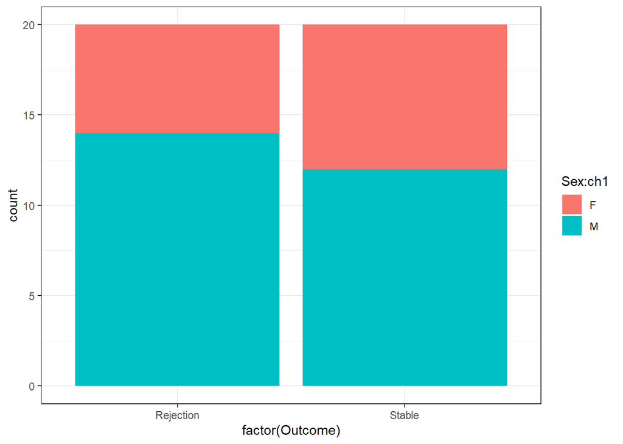

```r
ggplot(pData(gse), aes(x = factor(Outcome), fill = `Sex:ch1`)) + geom_bar(stat = "count") +
    theme_bw()
```

## 4.4 Quick visualisation

Before we perform any higher-level statistics, it is essential that we look at the data. What kind of graphics will you do? Are there any samples that appear to be significantly different from the others? Is it necessary to remove any samples (patients)?

```r
library(reshape2)
```

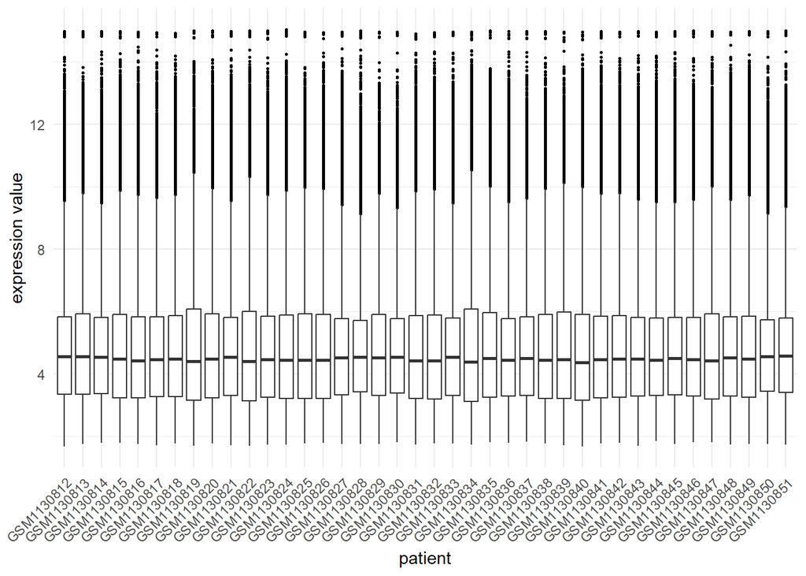

```r
p <- ggplot(melt(exprs(gse)), aes(x = Var2, y = value)) + geom_boxplot(outlier.colour = "black",
    outlier.shape = 16, outlier.size = 0.5, notch = FALSE) + theme(axis.text.x = element_text(angle = 180,
    hjust = 1)) + labs(x = "patient", y = "expression value") + theme_minimal() +
    theme(axis.text.x = element_text(angle = 45, vjust = 1, hjust = 1))
p
```

```r
summary(melt(exprs(gse))$value)
```

```
##    Min. 1st Qu.  Median    Mean 3rd Qu.    Max.
##     1.7     3.3     4.5     4.8     5.9    15.0
```